# Stat-rethink Chapter 4

Mariana CHiozza

6/15/2020

# Geocentric models

Linear regression (LR) as a family of simple statisitcal models that attempt to learn about the mean and variane of some measurement, using a combination of other measurements.

LR use Gaussian distribution to describe the model uncertainty of the measure of interest.

## Why normal distributions are normal

### Example 1. Position of 1000 people in a soccer field flipping a coin 16 times.

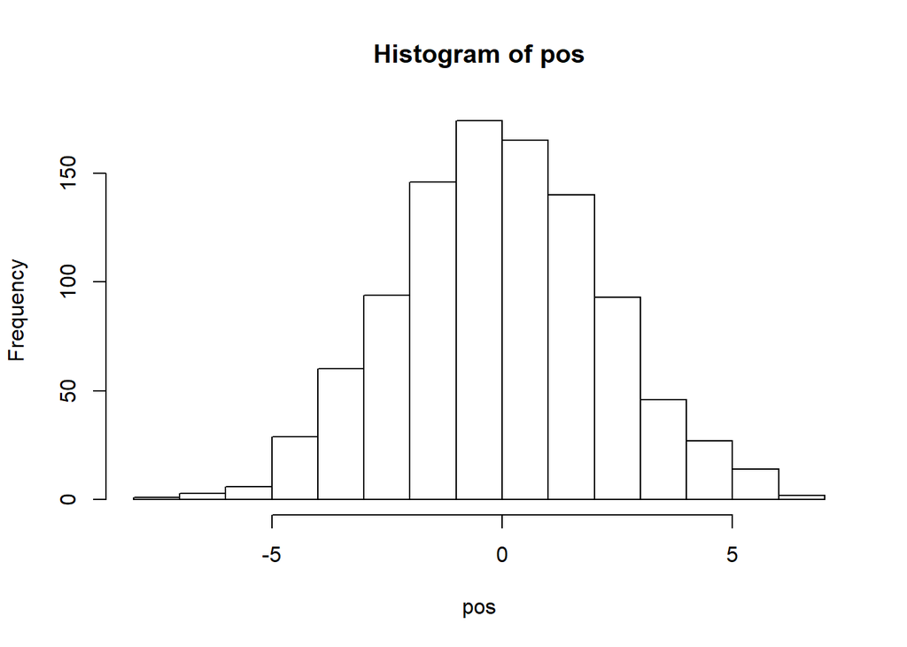

```r
pos <- replicate (1000, sum (runif(16, -1,1)))
hist(pos)
```

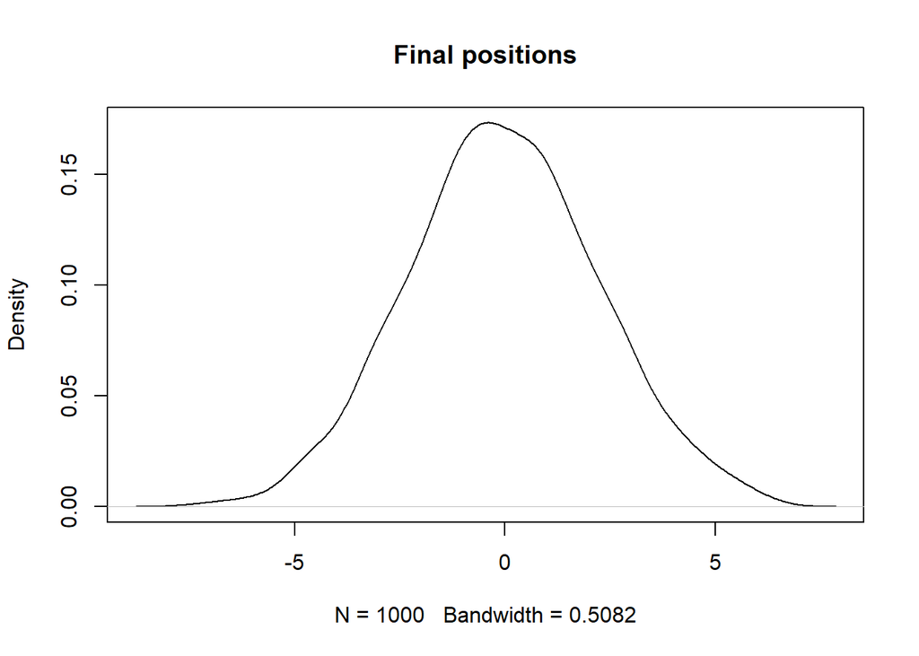

```r
plot(density(pos), main="Final positions")
```

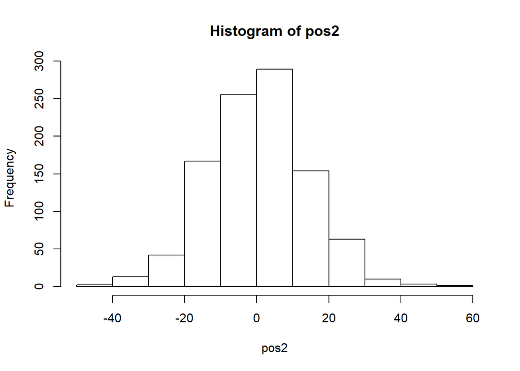

```r
pos2 <- replicate (1000, sum (runif(500, -1,1)))
hist(pos2)
```

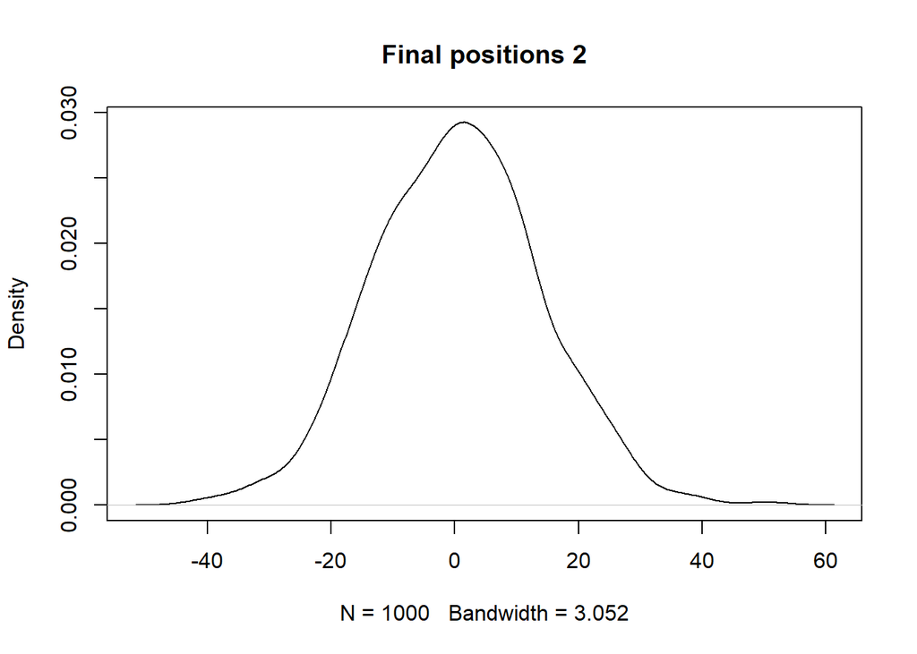

```r
plot(density(pos2), main="Final positions 2")
```

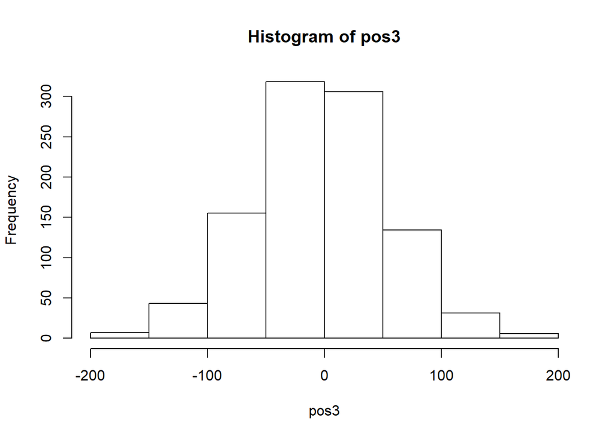

```r
pos3 <- replicate (1000, sum (runif(10000, -1,1)))
hist(pos3)
```

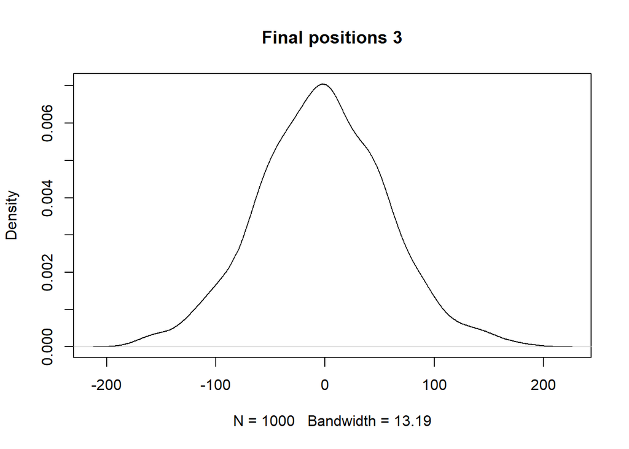

```r
plot(density(pos3), main="Final positions 3")
```

Adding random values to a distribution converges to a normal. Each sample is a deviation from the average. In the process of adding deviation, they will be canceled. THe more samples, the more chances to be canceled.

### Example 2. Growth rate as influenced by 12 loci that interact between each other (their effects multiply)

```r
prod(1+runif(12,0,0.1)) # generates random numbers between 1.0 and 1.1 representing a proportional increase in growth. These random products will have a normal distribution. Multiplying small numbers is similar to addition. Something similar happens by converting large deviates into logs. Adding logs will end up in a Gaussian distribution.
```

```
## [1] 1.831638
```

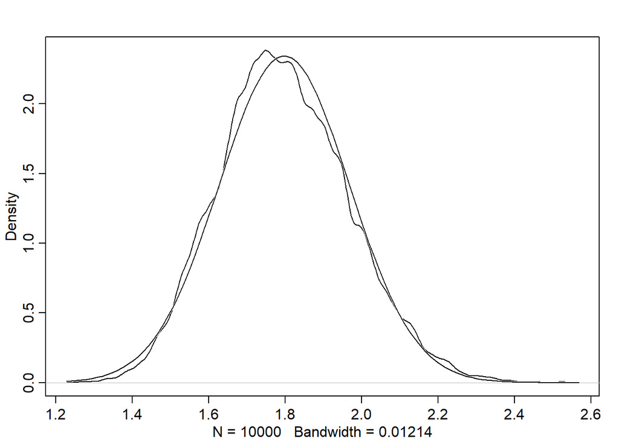

```r
growth<- replicate(10000, prod(1+runif(12,0,0.1)))
dens(growth , norm.comp=TRUE)
```

### Building a regression model

The posterior distribution will be a distribution of Gaussian distributions….

```r
library(rethinking)
data(Howell1)
d<-Howell1
str(d) # 0=female and 1=male
```

```
## 'data.frame':    544 obs. of  4 variables:
##  $ height: num  152 140 137 157 145 ...
##  $ weight: num  47.8 36.5 31.9 53 41.3 ...
##  $ age   : num  63 63 65 41 51 35 32 27 19 54 ...
##  $ male  : int  1 0 0 1 0 1 0 1 0 1 ...
```

```r
precis(d, hist=FALSE)
```

```
##               mean         sd      5.5%     94.5%
## height 138.2635963 27.6024476 81.108550 165.73500
## weight  35.6106176 14.7191782  9.360721  54.50289
## age     29.3443934 20.7468882  1.000000  66.13500
## male     0.4724265  0.4996986  0.000000   1.00000
```

```r
d2<-d[d$age>=18, ]
```

Model using a Gaussian distribution

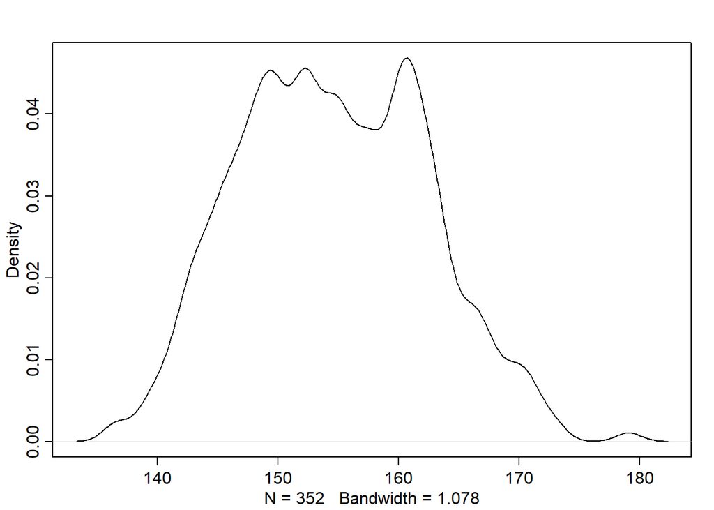

```r
dens(d2$height)
```

Which Gaussian distribution?? There are infinite number of Gaussian distributions with different combinations of mean and sd.

Plotting the Priors

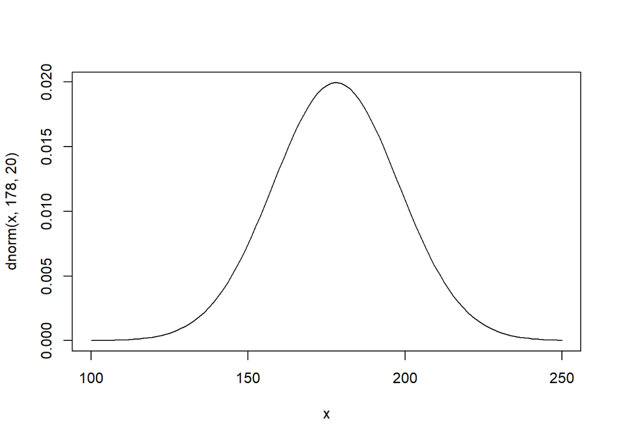

```r
curve (dnorm (x, 178, 20) , from=100, to=250)
```

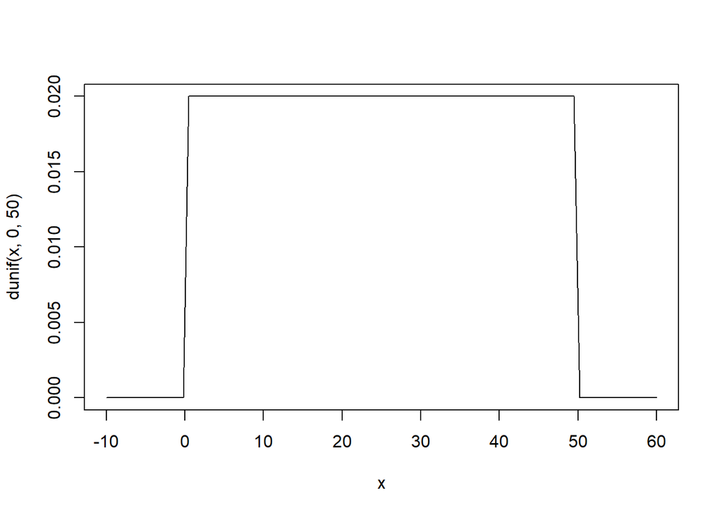

```r
curve (dunif(x,0,50), from=-10, to=60)
```

PRIOR PREDICTIVE, sampling from the prior to simulate heights. How to use the priors to simulate heights.

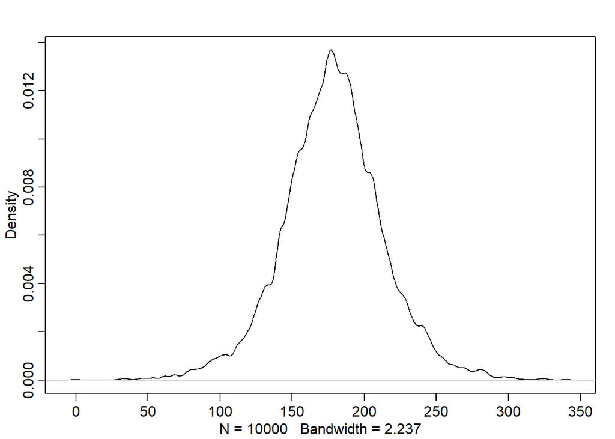

```r
sample_mu<-rnorm(10000, 178, 20)
sample_sigma<-runif(10000, 0, 50)
prior_h<-rnorm (10000, sample_mu, sample_sigma)
dens(prior_h)
```

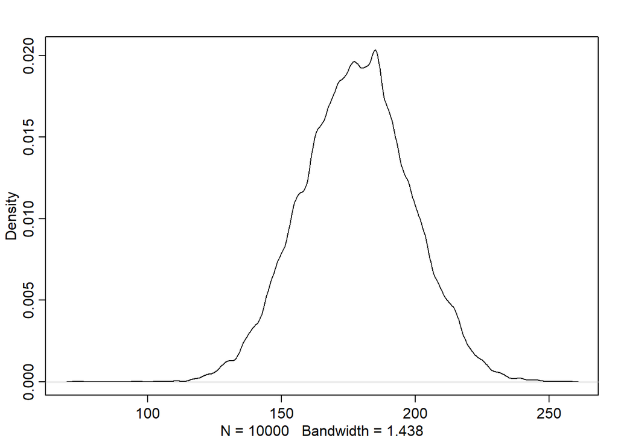

```r
dens(sample_mu)
```

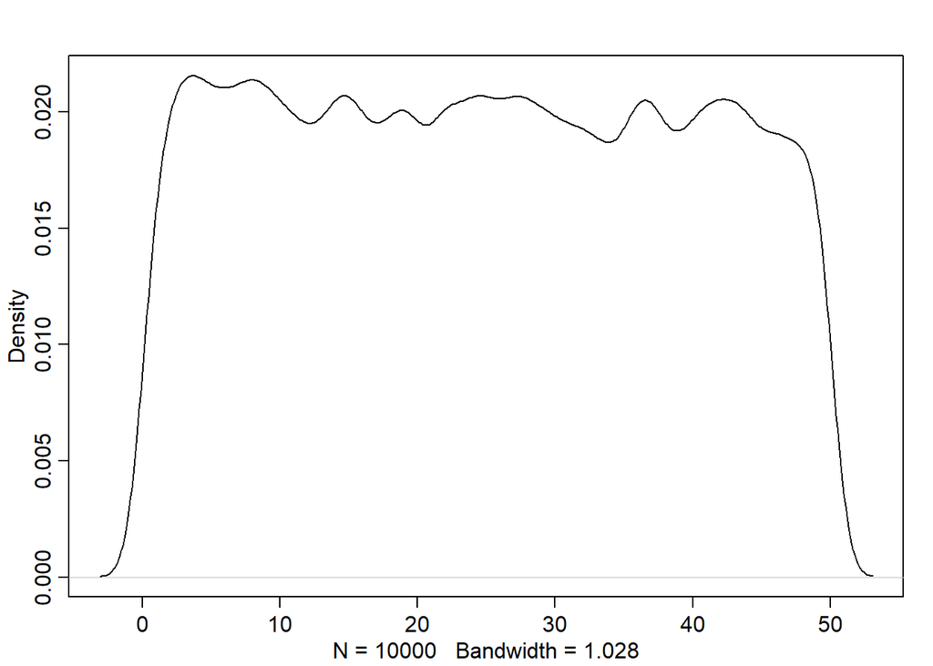

```r
dens(sample_sigma)
```

Grid approximation of the posterior distribution

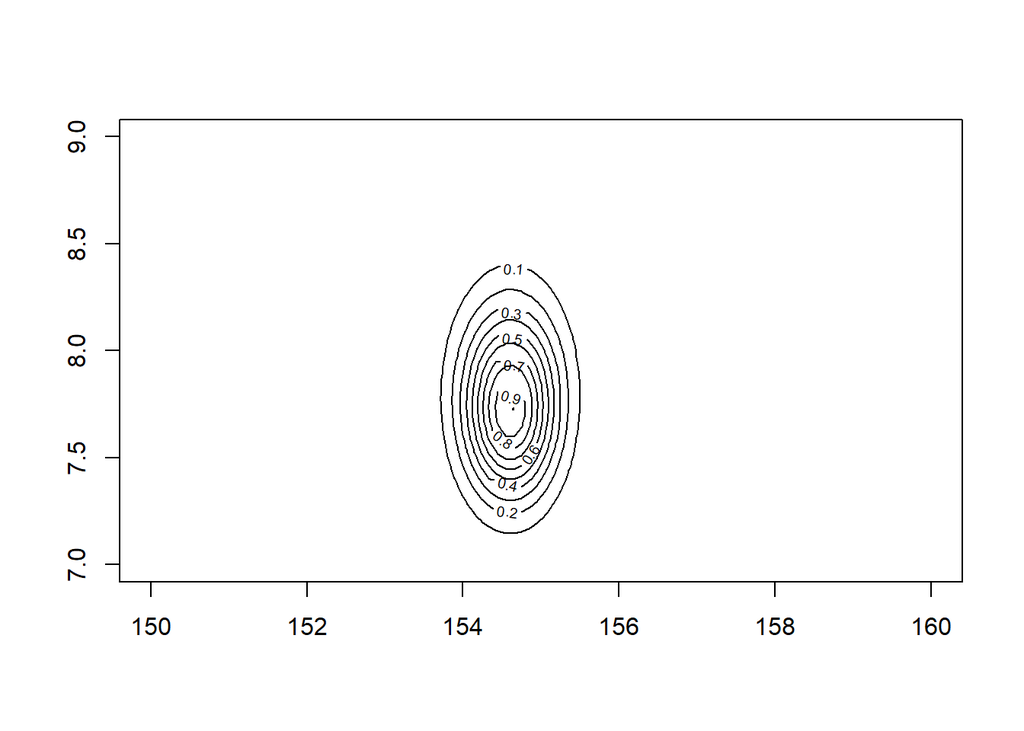

```r
mu.list<-seq(from=150, to=160, length.out=100)
sigma.list<-seq(from=7, to=9, length.out = 100)
post<-expand.grid(mu=mu.list, sigma=sigma.list)
post$LL<-sapply(1:nrow(post) , function (i) sum(
  dnorm(d2$height, post$mu[i], post$sigma[i], log=TRUE)))
post$prod<-post$LL + dnorm (post$mu, 178,20, TRUE) +
  dunif(post$sigma,0,50,TRUE)
post$prob<-exp(post$prod-max(post$prod))
contour_xyz(post$mu, post$sigma, post$prob)
```

Sampling the posterior

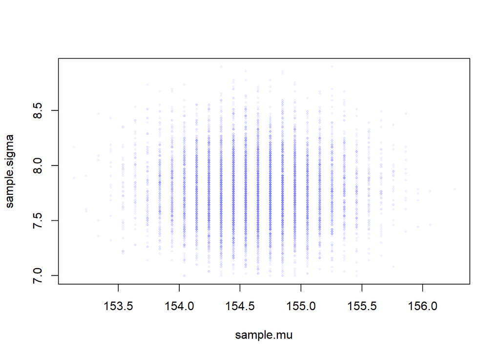

```r
sample.rows<-sample (1:nrow(post), size = 10000, replace = TRUE , prob=post$prob)
sample.mu=post$mu[sample.rows]
sample.sigma=post$sigma[sample.rows]
plot (sample.mu, sample.sigma, cex=0.5, pch=16, col=col.alpha(rangi2,0.1))
```

Finding the posterior distribution with quap: Quadratic approximation

```r
data(Howell1)
d<-Howell1
d2<-d[d$age>=18, ]

flist=alist(height~dnorm(mu, sigma),
            mu~dnorm(178,20),
            sigma~dunif(0,50))

m4.1=quap(flist,data=d2) #fir the model to the d2 data
precis(m4.1)
```

```
##             mean        sd       5.5%      94.5%
## mu    154.607125 0.4119984 153.948672 155.265578
## sigma   7.731402 0.2913925   7.265701   8.197104
```

```r
m4.2=quap(alist(height~dnorm(mu, sigma),
            mu~dnorm(178,0.1),
            sigma~dunif(0,50)), data=d2)

precis(m4.2) #Even though we chance the sd of the mu prior, the estimate of sigma changed a lot.
```

```
##            mean        sd      5.5%     94.5%
## mu    177.86375 0.1002354 177.70356 178.02395
## sigma  24.51756 0.9289235  23.03297  26.00216
```

Quadratic approximation is a multi-dimensional Gaussian distribution (a list of means and a matrix of variances and covariances).

```r
vcov(m4.1) # to see the matrix of variances and covariances for model m4.1
```

```
##                 mu        sigma
## mu    0.1697426507 0.0002202707
## sigma 0.0002202707 0.0849096147
```

```r
diag(vcov(m4.1)) # list of variances
```

```
##         mu      sigma
## 0.16974265 0.08490961
```

```r
cov2cor(vcov(m4.1)) # correlation matrix
```

```
##                mu       sigma
## mu    1.000000000 0.001834775
## sigma 0.001834775 1.000000000
```

Sampling the quadratic posterior.

Sampling vectors of values from the multi-dimensional posterior Gaussian distribution.

```r
post<-extract.samples(m4.1, n=10000)
head(post)
```

```
##         mu    sigma
## 1 154.1346 7.241792
## 2 154.4333 7.388795
## 3 155.3569 7.926821
## 4 153.9652 7.667500
## 5 155.0477 8.195606
## 6 155.3304 7.437058
```

```r
precis(post) # very similar to m4.1 model
```

```
##             mean        sd       5.5%      94.5%
## mu    154.604236 0.4098590 153.942201 155.251220
## sigma   7.732704 0.2902185   7.258066   8.195584
##                                                                                                      histogram
## mu                                                    ▁▁▅▇▂▁▁
## sigma ▁▁▁▁▂▅▇▇▃▁▁▁▁
```